# Homework 05

Shushi Meng (shushim2)

## 1

Seed: 5051. All KNN fits use equal weights and no intercept column.

a. f(x₀) = 0.5(0.5) + sin(0.7) − 0.3(1²) = 0.594218. The single-sample predictions and simulation estimates are below.

| k | One-sample prediction | Bias | Variance | MSE |
| --- | --- | --- | --- | --- |
| 1 | 0.678642 | -0.003624 | 0.036366 | 0.036379 |
| 3 | 0.473505 | -0.018786 | 0.017444 | 0.017797 |
| 5 | 0.479291 | -0.037027 | 0.014076 | 0.015447 |
| 7 | 0.522284 | -0.051220 | 0.011475 | 0.014099 |
| 9 | 0.607683 | -0.058966 | 0.009840 | 0.013317 |
| 11 | 0.578389 | -0.067398 | 0.008679 | 0.013221 |
| 13 | 0.524957 | -0.074880 | 0.008392 | 0.013999 |
| 15 | 0.557017 | -0.086020 | 0.009083 | 0.016482 |
| 17 | 0.546890 | -0.091738 | 0.009172 | 0.017588 |
| 19 | 0.568327 | -0.097381 | 0.008859 | 0.018342 |
| 21 | 0.611674 | -0.105731 | 0.008615 | 0.019794 |
| 23 | 0.616204 | -0.112949 | 0.008146 | 0.020903 |
| 25 | 0.624718 | -0.114178 | 0.007702 | 0.020739 |
| 27 | 0.591080 | -0.123361 | 0.007490 | 0.022708 |
| 29 | 0.531595 | -0.126651 | 0.007389 | 0.023430 |

b. For each k, bias = mean(predictions) − f(x₀), variance = mean((predictions − their mean)²), and MSE = mean((predictions − f(x₀))²). Each row of the 200 × 15 prediction matrix uses one newly generated training sample for every k.

The largest difference between MSE and bias² + variance is 8.67e-17. This is error in estimating the mean, so I do not add the new-response noise variance 0.01.

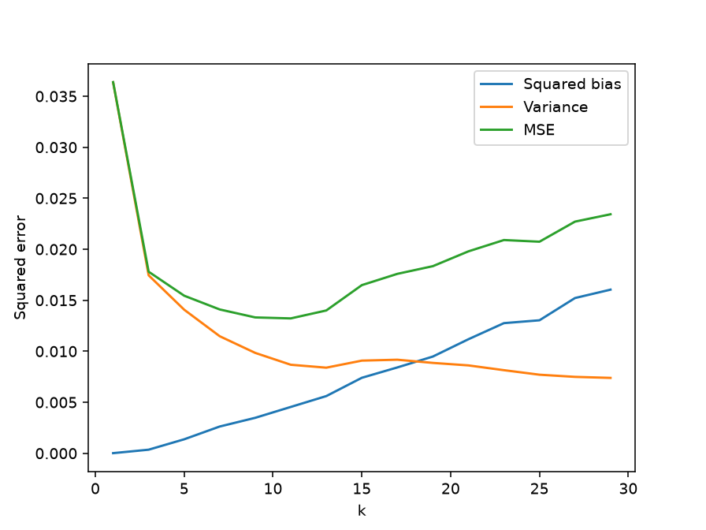

The smallest empirical MSE occurs at k = 11. Larger neighborhoods generally reduce variance but increase smoothing bias. The curves need not be perfectly smooth with 200 repetitions. Ridge and lasso have a similar trade-off when their penalty increases, but they shrink coefficients; KNN averages over a larger neighborhood. Here variance includes changing neighbor locations as well as response noise.

## 2

Seed: 5052. Each setting uses 400 training and 1,000 test observations, shared by both methods. 5NN uses the original covariate scale. For lasso, I use 10 folds and 41 penalties from 0.0001 to 1. Each fold estimates its own means and population-divisor standard deviations. I center y in that fold and add its training mean back to predictions, giving an unpenalized intercept. The final fit repeats these steps using all 400 training rows.

| Setting | 5NN test MSE | Lasso test MSE | Selected penalty | Nonzero slopes |
| --- | --- | --- | --- | --- |
| Independent | 0.537061 | 0.239867 | 0.031623 | 7 |
| Correlated | 0.155970 | 0.208453 | 0.025119 | 5 |

Lasso is better in the independent setting (0.240 versus 0.537). In the correlated setting, 5NN is better (0.156 versus 0.208). Both methods improve here, especially KNN.

b. Independent irrelevant coordinates add noise to KNN distances. With correlation, many coordinates share a common direction, which can make neighbors more useful for predicting the response. Lasso instead gives predictors separate coefficients and can set some to zero; correlated variables may also act as substitutes for one another.

c. Linear lasso cannot represent the sine and square terms exactly. KNN can follow nonlinear relationships if useful neighbors are available. This gives KNN a potential advantage, but irrelevant dimensions can offset it. These are just two random samples, not evidence that correlation always helps or either method is always better.

## 3

Seed: 5053. Each experiment draws a new A and 400 observations, split into 200 training and 200 test rows. Both halves share A. Only the 100 observed X variables enter KNN, on their original scale. I reuse the same data for all k within an experiment.

| k | Single MSE: m=3 | Single MSE: m=30 | Mean MSE: m=3 | Mean MSE: m=30 |
| --- | --- | --- | --- | --- |
| 2 | 1.528165 | 3.147266 | 1.676598 | 3.084366 |
| 10 | 1.221091 | 2.345023 | 1.263543 | 2.314894 |
| 18 | 1.295185 | 2.290559 | 1.278291 | 2.311958 |
| 26 | 1.340832 | 2.324235 | 1.326035 | 2.330240 |
| 34 | 1.422513 | 2.353811 | 1.376689 | 2.378416 |
| 42 | 1.506895 | 2.355765 | 1.432329 | 2.402281 |
| 50 | 1.559542 | 2.399794 | 1.487639 | 2.431957 |
| 58 | 1.631314 | 2.428912 | 1.546764 | 2.458501 |
| 66 | 1.721520 | 2.498652 | 1.602353 | 2.490341 |
| 74 | 1.784422 | 2.529422 | 1.662302 | 2.520877 |
| 82 | 1.845288 | 2.571247 | 1.723109 | 2.551019 |

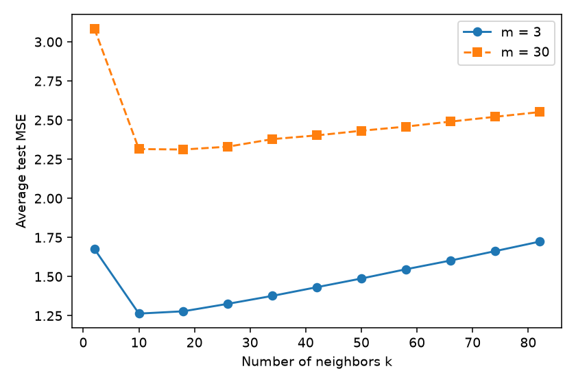

b. The graph averages 50 new experiments. It compares the given k values; it is not cross-validation or a final model-selection procedure.

The m = 3 curve is lower throughout. Among the tested values, its lowest average MSE is 1.264 at k = 10, compared with 2.312 at k = 18 for m = 30. Large neighborhoods eventually smooth away useful differences.

c. With m = 30, distances respond to many latent directions unrelated to Y. With m = 3, neighbors are more likely to be close in the two useful directions. Thus equal observed dimension and equal response dimension do not imply equal KNN performance. Measurement noise η adds variation in every observed direction and can change the neighbors. Without η, AZ lies in the column space of A; with η, X has covariance AAᵀ + I and is not confined to that lower-dimensional space.

## 4

a. I use the first 1,000 training rows and first 500 test rows, with all 256 original pixel values. The label is excluded. No seed is needed because this part is deterministic. Stable sorting keeps the smaller training row first in a distance tie; argmax chooses the smallest digit in a voting tie.

```
def classify5(train, labels, test, distance='euclidean'):
    predictions = []
    for image in test:
        difference = train-image
        if distance == 'euclidean':
            d = np.sqrt(np.sum(difference**2, axis=1))
        elif distance == 'manhattan':
            d = np.sum(np.abs(difference), axis=1)
        else:
            raise ValueError('Unknown distance')
        neighbors = np.argsort(d, kind='stable')[:5]
        votes = np.bincount(labels[neighbors], minlength=10)
        predictions.append(np.argmax(votes))
    return np.array(predictions)
```

b. Rows in both confusion matrices are predicted digits; columns are true digits.

Euclidean: 61/500 errors = 0.122.

| Predicted / True | 0 | 1 | 2 | 3 | 4 | 5 | 6 | 7 | 8 | 9 |
| --- | --- | --- | --- | --- | --- | --- | --- | --- | --- | --- |
| 0 | 118 | 0 | 7 | 1 | 0 | 4 | 2 | 0 | 2 | 0 |
| 1 | 0 | 66 | 0 | 0 | 2 | 0 | 0 | 0 | 0 | 1 |
| 2 | 0 | 0 | 39 | 1 | 0 | 0 | 2 | 0 | 0 | 1 |
| 3 | 0 | 0 | 0 | 23 | 0 | 4 | 0 | 0 | 2 | 0 |
| 4 | 0 | 0 | 1 | 0 | 27 | 1 | 1 | 1 | 0 | 1 |
| 5 | 0 | 0 | 0 | 1 | 0 | 13 | 0 | 0 | 0 | 0 |
| 6 | 0 | 2 | 0 | 0 | 0 | 1 | 41 | 0 | 2 | 0 |
| 7 | 0 | 0 | 0 | 0 | 1 | 1 | 0 | 34 | 0 | 4 |
| 8 | 0 | 0 | 3 | 2 | 0 | 2 | 0 | 0 | 37 | 0 |
| 9 | 1 | 0 | 0 | 1 | 4 | 0 | 0 | 1 | 1 | 41 |

Frequent mistakes (true → predicted): 2 → 0 (7); 5 → 0 (4); 5 → 3 (4); 9 → 7 (4).

Manhattan: 69/500 errors = 0.138.

| Predicted / True | 0 | 1 | 2 | 3 | 4 | 5 | 6 | 7 | 8 | 9 |
| --- | --- | --- | --- | --- | --- | --- | --- | --- | --- | --- |
| 0 | 118 | 0 | 6 | 1 | 0 | 5 | 3 | 0 | 4 | 0 |
| 1 | 0 | 67 | 2 | 0 | 2 | 0 | 1 | 0 | 0 | 1 |
| 2 | 0 | 0 | 35 | 0 | 0 | 0 | 2 | 0 | 0 | 0 |
| 3 | 0 | 0 | 1 | 24 | 0 | 4 | 0 | 0 | 2 | 0 |
| 4 | 0 | 0 | 1 | 1 | 27 | 1 | 0 | 1 | 0 | 1 |
| 5 | 0 | 0 | 0 | 1 | 0 | 11 | 0 | 0 | 0 | 0 |
| 6 | 0 | 1 | 0 | 0 | 0 | 2 | 40 | 0 | 2 | 0 |
| 7 | 0 | 0 | 2 | 1 | 1 | 0 | 0 | 34 | 0 | 5 |
| 8 | 0 | 0 | 2 | 0 | 0 | 3 | 0 | 0 | 34 | 0 |
| 9 | 1 | 0 | 1 | 1 | 4 | 0 | 0 | 1 | 2 | 41 |

Frequent mistakes (true → predicted): 2 → 0 (6); 5 → 0 (5); 9 → 7 (5); 8 → 0 (4).

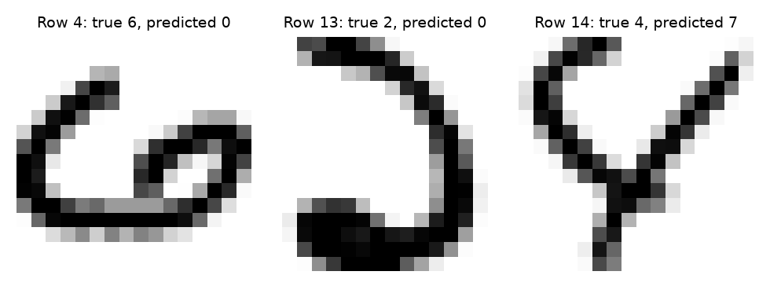

c. The round lower part of the 6 helps explain the prediction of 0. The 2 is heavily curved, and the 4 has an unusual slanted shape. The errors are understandable from raw pixels, although the labels are still recognizable to a person.

|  | Manhattan correct | Manhattan wrong |
| --- | --- | --- |
| Euclidean correct | 428 | 11 |
| Euclidean wrong | 3 | 58 |

The methods disagree on 22 predictions. Euclidean alone is correct on 11 images, Manhattan alone on 3, and both are wrong with different labels on 8. Thus similar error rates can hide different mistakes. Euclidean is slightly better on this split.

## 5

a. The final skill is appended below. It is limited to STAT 432 plots and requires an explicit request. The rules cover margins, titles, axes, labels, colors, and figure sizes in R or Python.

b. As part of my request to complete Question 5, the agent created and installed stat432-plain-plots in the personal skills directory and explicitly applied it to the Question 1 plot. Automatic invocation is disabled in agents/openai.yaml. One version was tested and kept.

Original:

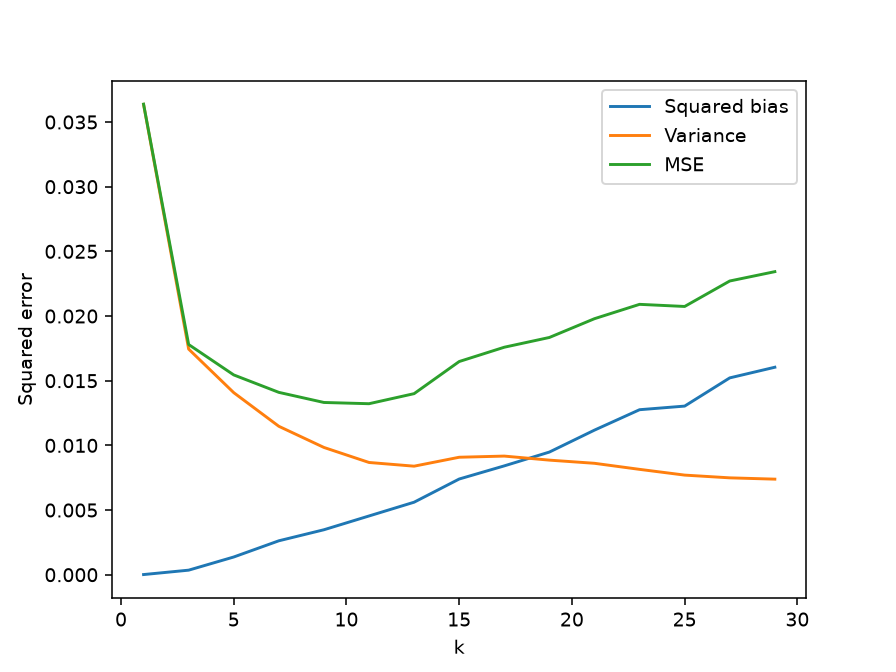

After applying the skill:

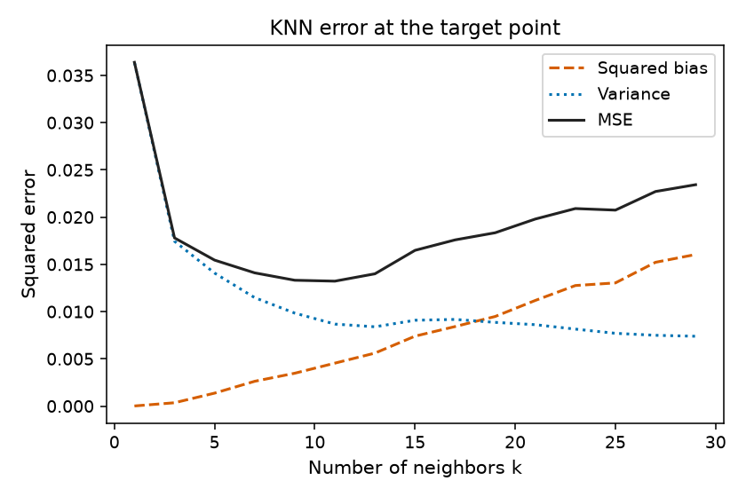

c. The revised version has a short title, a clearer x-axis label, distinct line styles, and adjusted margins. The numerical curves are unchanged. It is a modest readability improvement that keeps the plot plain. The skill avoids decorations and keeps the original for comparison. This describes the agent-assisted test; my own preference can be checked by comparing the two plots.

```
---
name: stat432-plain-plots
description: Improve R or Python plots for STAT 432 homework only when explicitly requested by the user. Do not apply automatically.
---

# Simple STAT 432 plots

- Keep the data, calculations, and axis meaning unchanged.
- Leave enough margins for labels and legends. In Python use tight_layout; in R adjust par(mar) if needed.
- Add a short descriptive title, with no subtitle unless needed.
- Label both axes in plain words, include units where relevant, and avoid crowded ticks.
- Use a white background and two or three readable colors. Distinguish curves with line styles as well as color.
- Start around 6 by 4 inches, with 11-point labels and a 12-point title; adjust for multiple panels.
- Keep the original plot for comparison. Avoid decorative backgrounds, oversized text, and extra annotations.
```

## Calculation code

The code below records the computations used above. Python packages: NumPy, SciPy, scikit-learn, Matplotlib. The course solution was used as a reference; the reported values come from running this code. AI assisted with coding and drafting.

```
import numpy as np
from scipy.spatial.distance import cdist
from sklearn.linear_model import Lasso

def f(x):
    return 0.5*x[:, 0] + np.sin(x[:, 1]) - 0.3*x[:, 2]**2


def regress_all_k(train, y, test, ks):
    order = np.argsort(cdist(test, train, metric='sqeuclidean'), axis=1, kind='stable')
    sums = np.cumsum(y[order], axis=1)
    return sums[:, ks-1] / ks


# Q1: one data set, followed by 200 fresh data sets.
rng = np.random.default_rng(5051)
ks1 = np.arange(1, 30, 2)
x0 = np.array([[0.5, 0.7, 1.]])
truth = f(x0)[0]


def prediction_q1():
    x = rng.normal(size=(400, 3))
    y = f(x) + rng.normal(0, 0.1, 400)
    return regress_all_k(x, y, x0, ks1)[0]


one1 = prediction_q1()
pred1 = np.array([prediction_q1() for _ in range(200)])
bias = pred1.mean(axis=0) - truth
variance = pred1.var(axis=0, ddof=0)
mse1 = ((pred1-truth)**2).mean(axis=0)
gap = np.max(np.abs(mse1-bias**2-variance))

print(np.column_stack([ks1, one1, bias, variance, mse1]))

# Q2: manual fold-specific scaling and response centering.
rng = np.random.default_rng(5052)
penalties = np.logspace(-4, 0, 41)
rows2 = []
for rho in [0., 0.8]:
    covariance = rho*np.ones((30, 30)) + (1-rho)*np.eye(30)
    x = rng.normal(size=(1400, 30)) @ np.linalg.cholesky(covariance).T
    y = f(x) + rng.normal(0, 0.1, 1400)
    train, test = x[:400], x[400:]
    yt, ytest = y[:400], y[400:]
    knn_pred = regress_all_k(train, yt, test, np.array([5]))[:, 0]
    fold = rng.permutation(np.repeat(np.arange(10), 40))
    errors = np.empty((10, 41))
    for j in range(10):
        fit, valid = fold != j, fold == j
        center = train[fit].mean(axis=0)
        scale = train[fit].std(axis=0, ddof=0)
        xf = (train[fit]-center)/scale
        xv = (train[valid]-center)/scale
        ymean = yt[fit].mean()
        for h, penalty in enumerate(penalties):
            model = Lasso(alpha=penalty, fit_intercept=False, tol=1e-8, max_iter=100000)
            model.fit(xf, yt[fit]-ymean)
            errors[j, h] = np.mean((yt[valid] - model.predict(xv)-ymean)**2)
    penalty = penalties[np.argmin(errors.mean(axis=0))]
    center, scale, ymean = train.mean(axis=0), train.std(axis=0, ddof=0), yt.mean()
    model = Lasso(alpha=penalty, fit_intercept=False, tol=1e-8, max_iter=100000)
    model.fit((train-center)/scale, yt-ymean)
    lasso_pred = model.predict((test-center)/scale) + ymean
    rows2.append(['Independent' if rho == 0 else 'Correlated', np.mean((knn_pred-ytest)**2), np.mean((lasso_pred-ytest)**2), penalty, np.count_nonzero(model.coef_)])

print(rows2)

# Q3: one fresh loading matrix per experiment, shared by train and test.
rng = np.random.default_rng(5053)
ks3 = np.arange(2, 83, 8)


def experiment(m):
    a = rng.uniform(-2, 2, (100, m))
    z = rng.normal(size=(400, m))
    x = z @ a.T + rng.normal(size=(400, 100))
    y = z[:, 0] + z[:, 1] + rng.normal(size=400)
    predictions = regress_all_k(x[:200], y[:200], x[200:], ks3)
    return np.mean((predictions-y[200:, None])**2, axis=0)


one3 = np.column_stack([experiment(m) for m in [3, 30]])
repeat3 = np.array([np.column_stack([experiment(m) for m in [3, 30]]) for _ in range(50)])
avg3 = repeat3.mean(axis=0)

print(one3)
print(avg3)
```